# Data Analysis on bike share stations

Quoc Hoang Vu

2024-11-22

Import the `dplyr` library to better manipulate data:

```r
if (!require("dplyr")) {
  install.packages("dplyr")
  library("dplyr")
}
```

Import the `ggplot2` library to draw plots:

```r
if (!require("ggplot2")) {
  install.packages("ggplot2")
  library("ggplot2")
}
```

Import the `igraph` library to work with graphs:

```r
if (!require("igraph")) {
  install.packages("igraph")
  library("igraph")
}
```

We read the following datasets:

- A file comprising a description of each bike share station
- A file containing trips between bike stations on Monday 7 July 2014 to Sunday 13 July 2014
- A file containing trips between bike stations on Monday 5 January 2015 to Sunday 11 January 2015
- A file containing trips between bike stations on Monday 6 July 2015 to Sunday 12 July 2015

```r
stations <- read.csv("https://raw.githubusercontent.com/julien-arino/math-of-data-science/refs/heads/main/CODE/SF-bikeshare-station-info.csv")
trips_07072014_13072014 <- read.csv("https://raw.githubusercontent.com/julien-arino/math-of-data-science/refs/heads/main/CODE/SF-bikeshare-1-week-2014-07.csv")
trips_05012015_11012015 <- read.csv("https://raw.githubusercontent.com/julien-arino/math-of-data-science/refs/heads/main/CODE/SF-bikeshare-1-week-2015-01.csv")
trips_06072015_12072015 <- read.csv("https://raw.githubusercontent.com/julien-arino/math-of-data-science/refs/heads/main/CODE/SF-bikeshare-1-week-2015-07.csv")
```

We wish to get a concrete idea of what each dataset contains. We can use `head()` to get the first few entries of a dataset, and `dim()` to get the size of a dataset.

We examine the bike share station dataset, which we denote as `stations`:

```r
head(stations)
```

|  | id | name | lat | long | dock_count | city | installation_date |
| --- | --- | --- | --- | --- | --- | --- | --- |
| 1 | 2 | San Jose Diridon Caltrain Station | 37.32973 | -121.9018 | 27 | San Jose | 8/6/2013 |
| 2 | 3 | San Jose Civic Center | 37.33070 | -121.8890 | 15 | San Jose | 8/5/2013 |
| 3 | 4 | Santa Clara at Almaden | 37.33399 | -121.8949 | 11 | San Jose | 8/6/2013 |
| 4 | 5 | Adobe on Almaden | 37.33141 | -121.8932 | 19 | San Jose | 8/5/2013 |
| 5 | 6 | San Pedro Square | 37.33672 | -121.8941 | 15 | San Jose | 8/7/2013 |
| 6 | 7 | Paseo de San Antonio | 37.33380 | -121.8869 | 15 | San Jose | 8/7/2013 |

```r
dim(stations)
```

```
## [1] 70  7
```

We make the following observations:

- The dataset has 70 entries and 7 columns.
- The first column contains the `id` of the bike share station (interestingly, this doesn’t start at 1).
- The second column contains the `name` of the bike share station.
- The third column contains the `latitude` (positionally) of the bike share station.
- The fourth column contains the `longtitude` (positionally) of the bike share station.
- The fifth column contains the `dock_count` of the bike share station (how many bikes are available).
- The sixth column contains the `city` the bike share station is located in.
- The seventh column contains the `installation_date` of the bike share station.

We examine the trips between bike stations on Monday 7 July 2014 to Sunday 13 July 2014 dataset, which we denote as `trips_07072014_13072014`:

```r
head(trips_07072014_13072014)
```

|  | start_date_yyyymmdd | start_station_name | start_station_id | end_date_yyyymmdd | end_station_name | end_station_id | duration |
| --- | --- | --- | --- | --- | --- | --- | --- |
| 1 | 2014-07-13 | Powell at Post (Union Square) | 71 | 2014-07-13 | Embarcadero at Bryant | 54 | 667 |
| 2 | 2014-07-13 | Market at 4th | 76 | 2014-07-13 | Market at 10th | 67 | 401 |
| 3 | 2014-07-13 | Market at 4th | 76 | 2014-07-13 | Market at 10th | 67 | 401 |
| 4 | 2014-07-13 | Grant Avenue at Columbus Avenue | 73 | 2014-07-13 | Powell at Post (Union Square) | 71 | 470 |
| 5 | 2014-07-13 | Harry Bridges Plaza (Ferry Building) | 50 | 2014-07-13 | Howard at 2nd | 63 | 421 |
| 6 | 2014-07-13 | San Jose Diridon Caltrain Station | 2 | 2014-07-13 | Santa Clara at Almaden | 4 | 221 |

```r
dim(trips_07072014_13072014)
```

```
## [1] 6911    7
```

We make the following observations:

- The dataset has 6911 entries and 7 columns.
- The first column contains the `start_date_yyyymmdd` of the trip, or the starting date.
- The second column contains the `start_station_name` of the trip, or the name of the starting station.
- The third column contains the `start_station_id` of the trip, or the ID of the starting station.
- The fourth column contains the `end_date_yyyymmdd` of the trip, or the starting date.
- The fifth column contains the `end_station_name` of the trip, or the name of the ending station.
- The sixth column contains the `end_station_id` of the trip, or the ID of the ending station.
- The seventh column contains the `duration` of the trip in seconds.

We examine the trips between bike stations on Monday 5 January 2015 to Sunday 11 January 2015 dataset, which we denote as `trips_05012015_11012015`:

```r
head(trips_05012015_11012015)
```

|  | start_date_yyyymmdd | start_station_name | start_station_id | end_date_yyyymmdd | end_station_name | end_station_id | duration |
| --- | --- | --- | --- | --- | --- | --- | --- |
| 1 | 2015-01-11 | Embarcadero at Sansome | 60 | 2015-01-11 | Civic Center BART (7th at Market) | 72 | 962 |
| 2 | 2015-01-11 | San Jose Diridon Caltrain Station | 2 | 2015-01-11 | Santa Clara at Almaden | 4 | 236 |
| 3 | 2015-01-11 | San Francisco Caltrain (Townsend at 4th) | 70 | 2015-01-11 | Powell at Post (Union Square) | 71 | 653 |
| 4 | 2015-01-11 | 5th at Howard | 57 | 2015-01-11 | Powell at Post (Union Square) | 71 | 265 |
| 5 | 2015-01-11 | Grant Avenue at Columbus Avenue | 73 | 2015-01-11 | Powell Street BART | 39 | 608 |
| 6 | 2015-01-11 | 5th at Howard | 57 | 2015-01-11 | San Francisco City Hall | 58 | 540 |

```r
dim(trips_05012015_11012015)
```

```
## [1] 6899    7
```

We can see the columns are the same as the prior dataset. There are 6899 entries in the dataset.

We examine the trips between bike stations on Monday 6 July 2015 to Sunday 12 July 2015 dataset, which we denote as `trips_06072015_12072015`:

```r
head(trips_06072015_12072015)
```

|  | start_date_yyyymmdd | start_station_name | start_station_id | end_date_yyyymmdd | end_station_name | end_station_id | duration |
| --- | --- | --- | --- | --- | --- | --- | --- |
| 1 | 2015-07-12 | Howard at 2nd | 63 | 2015-07-12 | Market at Sansome | 77 | 121 |
| 2 | 2015-07-12 | Temporary Transbay Terminal (Howard at Beale) | 55 | 2015-07-12 | Powell Street BART | 39 | 444 |
| 3 | 2015-07-12 | San Jose City Hall | 10 | 2015-07-12 | SJSU - San Salvador at 9th | 16 | 444 |
| 4 | 2015-07-12 | Clay at Battery | 41 | 2015-07-12 | Washington at Kearny | 46 | 166 |
| 5 | 2015-07-12 | Market at Sansome | 77 | 2015-07-12 | Grant Avenue at Columbus Avenue | 73 | 624 |
| 6 | 2015-07-12 | Davis at Jackson | 42 | 2015-07-12 | Spear at Folsom | 49 | 363 |

```r
dim(trips_06072015_12072015)
```

```
## [1] 7381    7
```

We can again see the columns are the same as the prior dataset. There are 7381 entries in the dataset.

To further the analysis, we wish to merge the datasets into one big dataset. To better differentiate which data item belongs to which initial dataset, we add an extra column to each dataset called `month` describing the month of each dataset:

- `trips_07072014_13072014` will be `July 2014`
- `trips_05012015_11012015` will be `January 2015`
- `trips_06072015_12072015` will be `July 2015`

```r
trips_07072014_13072014$month <- "July 2014"
trips_05012015_11012015$month <- "January 2015"
trips_06072015_12072015$month <- "July 2015"

trips <- rbind(trips_07072014_13072014, trips_05012015_11012015, trips_06072015_12072015)
```

Now, we plot respectively how many times there was a bike trip in the first full week of each recorded month:

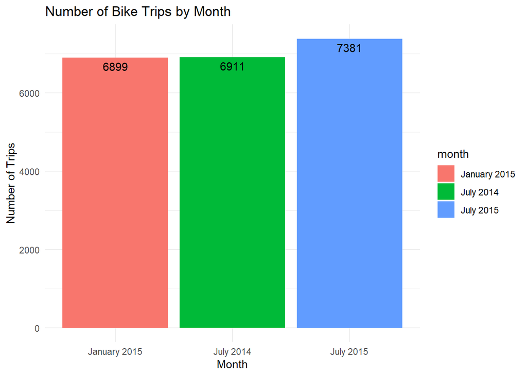

```r
ggplot(trips, aes(x = month, y = after_stat(count),  fill = month)) +
  geom_bar() +
  geom_text(stat = "count", aes(label = after_stat(count)), vjust = 1.5) +
  labs(title = "Number of Bike Trips by Month",
       x = "Month",
       y = "Number of Trips") +
  theme_minimal()
```

Regardless, this doesn’t tell us much: we only have three data points compromising of how many total trips are made. This would not suggest, for example, the number of trips made in January 2016 would be less than July 2015, or the number of trips made in July 2016 would increase from prior months.

The data we *do* have an abundance of is the individual trips themselves. Using `dim()` on the combined dataset:

```r
dim(trips)
```

```
## [1] 21191     8
```

There are 21191 total rows across the three datasets, and each row is an individual trip. We can, for example, identify the most popular starting and ending stations for each month. We will generate data frames for the top 5 most popular starting stations and ending stations for each dataset, with their corresponding frequency in the dataset.

For Monday 7 July 2014 to Sunday 13 July 2014:

```r
top_stations_j14 <- trips_07072014_13072014 %>%
  reframe(
    top_start = names(sort(table(start_station_name), decreasing = TRUE)[1:5]),
    top_start_freq = sort(table(start_station_name), decreasing = TRUE)[1:5],
    top_end = names(sort(table(end_station_name), decreasing = TRUE)[1:5]),
    top_end_freq = sort(table(end_station_name), decreasing = TRUE)[1:5]
  )

top_stations_j14
```

| top_start | top_start_freq | top_end | top_end_freq |
| --- | --- | --- | --- |
| San Francisco Caltrain (Townsend at 4th) | 546 | San Francisco Caltrain (Townsend at 4th) | 716 |
| Harry Bridges Plaza (Ferry Building) | 315 | Market at Sansome | 341 |
| San Francisco Caltrain 2 (330 Townsend) | 314 | San Francisco Caltrain 2 (330 Townsend) | 339 |
| Market at Sansome | 302 | Harry Bridges Plaza (Ferry Building) | 333 |
| Temporary Transbay Terminal (Howard at Beale) | 275 | Embarcadero at Sansome | 325 |

For Monday 5 January 2015 to Sunday 11 January 2015:

```r
top_stations_a15 <- trips_05012015_11012015 %>%
  reframe(
    top_start = names(sort(table(start_station_name), decreasing = TRUE)[1:5]),
    top_start_freq = sort(table(start_station_name), decreasing = TRUE)[1:5],
    top_end = names(sort(table(end_station_name), decreasing = TRUE)[1:5]),
    top_end_freq = sort(table(end_station_name), decreasing = TRUE)[1:5]
  )

top_stations_a15
```

| top_start | top_start_freq | top_end | top_end_freq |
| --- | --- | --- | --- |
| San Francisco Caltrain (Townsend at 4th) | 643 | San Francisco Caltrain (Townsend at 4th) | 809 |
| San Francisco Caltrain 2 (330 Townsend) | 372 | San Francisco Caltrain 2 (330 Townsend) | 401 |
| Harry Bridges Plaza (Ferry Building) | 323 | Harry Bridges Plaza (Ferry Building) | 324 |
| Townsend at 7th | 296 | Townsend at 7th | 320 |
| Temporary Transbay Terminal (Howard at Beale) | 291 | 2nd at Townsend | 286 |

For 6 July 2015 to Sunday 12 July 2015:

```r
top_stations_j15 <- trips_06072015_12072015 %>%
  reframe(
    top_start = names(sort(table(start_station_name), decreasing = TRUE)[1:5]),
    top_start_freq = sort(table(start_station_name), decreasing = TRUE)[1:5],
    top_end = names(sort(table(end_station_name), decreasing = TRUE)[1:5]),
    top_end_freq = sort(table(end_station_name), decreasing = TRUE)[1:5]
  )

top_stations_j15
```

| top_start | top_start_freq | top_end | top_end_freq |
| --- | --- | --- | --- |
| San Francisco Caltrain 2 (330 Townsend) | 491 | San Francisco Caltrain (Townsend at 4th) | 639 |
| San Francisco Caltrain (Townsend at 4th) | 455 | San Francisco Caltrain 2 (330 Townsend) | 533 |
| Harry Bridges Plaza (Ferry Building) | 423 | Harry Bridges Plaza (Ferry Building) | 411 |
| Embarcadero at Sansome | 367 | Embarcadero at Sansome | 403 |
| 2nd at Townsend | 333 | 2nd at Townsend | 327 |

We better visualize the previous data using `ggplot`:

```
## Defaulting to continuous.
```

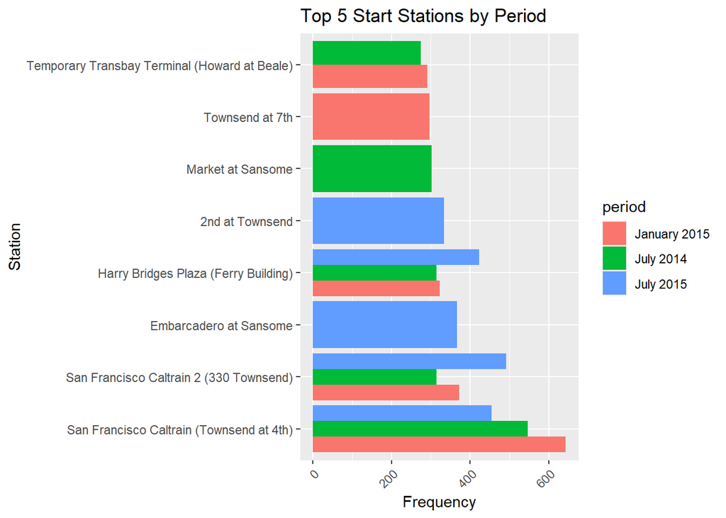

```r
top_stations <- as.data.frame(rbind(
  mutate(top_stations_j14, period = "July 2014"),
  mutate(top_stations_a15, period = "January 2015"),
  mutate(top_stations_j15, period = "July 2015")
))

ggplot(top_stations, aes(x = reorder(top_start, -top_start_freq), y = top_start_freq, fill = period)) +
  geom_bar(stat = "identity", position = "dodge") +
  theme(axis.text.x = element_text(angle = 45, hjust = 1)) +
  labs(title = "Top 5 Start Stations by Period", x = "Station", y = "Frequency") +
  coord_flip()
```

```
## Defaulting to continuous.
```

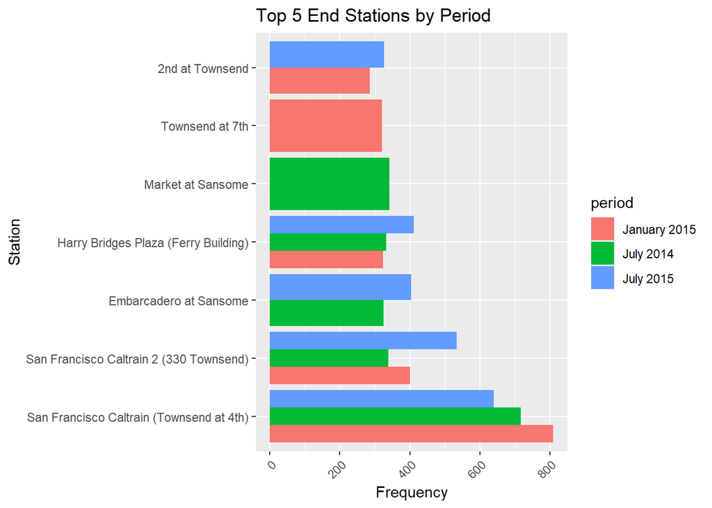

```r
ggplot(top_stations, aes(x = reorder(top_end, -top_end_freq), y = top_end_freq, fill = period)) +
  geom_bar(stat = "identity", position = "dodge") +
  theme(axis.text.x = element_text(angle = 45, hjust = 1)) +
  labs(title = "Top 5 End Stations by Period", x = "Station", y = "Frequency") +
  coord_flip()
```

To further understand these hot spots, we wish to model the network of bike stations as a graph. We will focus on only the top stations, so we want to define a function that generate a graph given the dataset and the stations we’re interested in (so the graph will only include trips to and from said stations).

```r
create_focused_graph <- function(trips_data, top_stations) {
  top_station_ids <- unique(c(top_stations$top_start, top_stations$top_end))
  filtered_trips <- trips_data %>%
    filter(start_station_name %in% top_station_ids | end_station_name %in% top_station_ids)

  edges <- filtered_trips %>%
    group_by(start_station_name, end_station_name) %>%
    summarise(weight = n(), .groups = "drop")

  graph <- graph_from_data_frame(edges, directed = TRUE)
  return(graph)
}
```

We now create and plot graphs for each dataset:

```r
graph_j14 <- create_focused_graph(trips_07072014_13072014, top_stations_j14)
graph_a15 <- create_focused_graph(trips_05012015_11012015, top_stations_a15)
graph_j15 <- create_focused_graph(trips_06072015_12072015, top_stations_j15)

plot_focused_graph <- function(graph, title) {
  set.seed(123)  # For reproducibility

  # Calculate node degrees
  node_degrees <- degree(graph, mode = "total")

  # Create a color palette based on node degrees
  color_palette <- colorRampPalette(c("lightblue", "darkblue"))(max(node_degrees) + 1)

  # Set node colors based on degree
  V(graph)$color <- color_palette[node_degrees + 1]

  # Calculate edge weights
  edge_weights <- E(graph)$weight

  # Normalize edge weights for visualization
  normalized_weights <- (edge_weights - min(edge_weights)) / (max(edge_weights) - min(edge_weights))

  # Set edge width based on normalized weights
  E(graph)$width <- 1 + 5 * normalized_weights

  # Use Fruchterman-Reingold layout for better spacing
  layout <- layout_with_fr(graph)

  # Plot the graph
  plot(graph,
       layout = layout,
       vertex.size = 5,  # Adjust node size based on degree
       vertex.label = "",
       vertex.label.cex = 0.6,
       vertex.label.color = "black",
       vertex.label.dist = 0.5,
       edge.arrow.size = 0.1,
       edge.curved = 0.1,
       main = title)

  # Add a legend for node degrees
  legend("bottomright",
         legend = c("Low", "Medium", "High"),
         fill = color_palette[c(1, floor(max(node_degrees)/2), max(node_degrees))],
         title = "Node Degree",
         cex = 0.8)
}
```

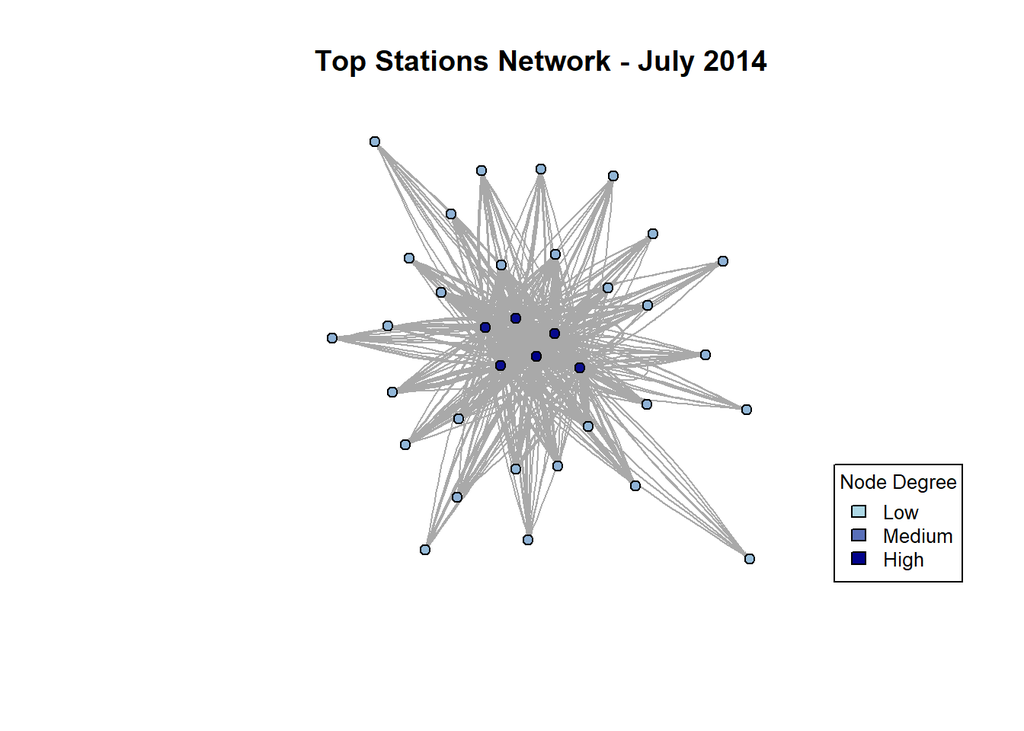

```r
plot_focused_graph(graph_j14, "Top Stations Network - July 2014")
```

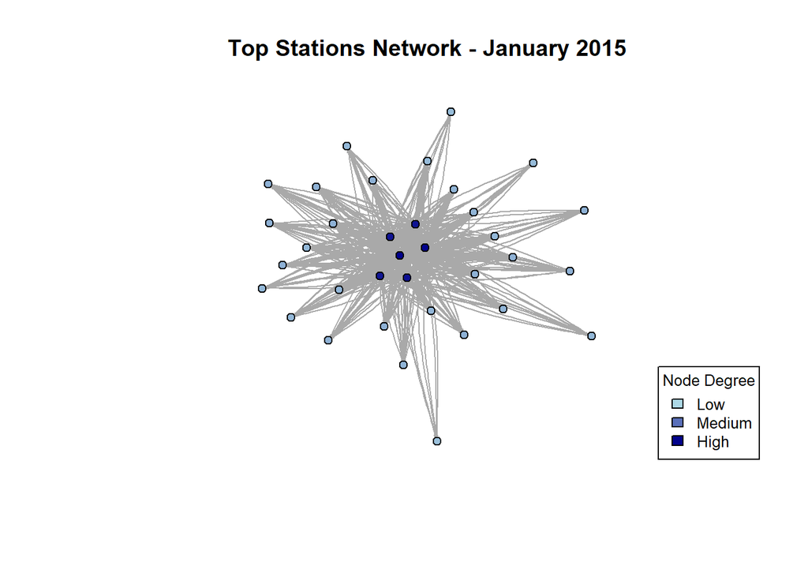

```r
plot_focused_graph(graph_a15, "Top Stations Network - January 2015")
```

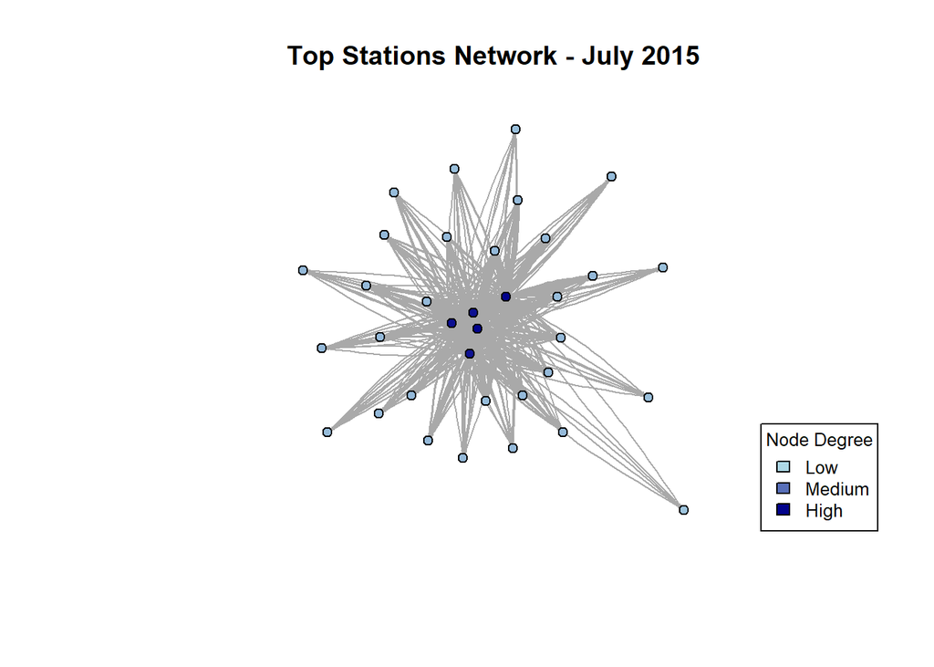

```r
plot_focused_graph(graph_j15, "Top Stations Network - July 2015")
```

Though the graph’s too cluttered…we note that there are only 6 central stations (5 in the case of July 2015) that connect to and from other stations. We may want to calculate some graph measures of these graphs, such as order, size, density, average degree, diameter, and average path length:

```r
calculate_graph_measures <- function(graph) {
  list(
    nodes = vcount(graph),
    edges = ecount(graph),
    density = edge_density(graph),
    avg_degree = mean(degree(graph)),
    diameter = diameter(graph),
    avg_path_length = average.path.length(graph)
  )
}

measures_j14 <- calculate_graph_measures(graph_j14)
measures_a15 <- calculate_graph_measures(graph_a15)
measures_j15 <- calculate_graph_measures(graph_j15)

measures_df <- data.frame(
  Period = c("July 2014", "January 2015", "July 2015"),
  Nodes = c(measures_j14$nodes, measures_a15$nodes, measures_j15$nodes),
  Edges = c(measures_j14$edges, measures_a15$edges, measures_j15$edges),
  Density = c(measures_j14$density, measures_a15$density, measures_j15$density),
  Avg_Degree = c(measures_j14$avg_degree, measures_a15$avg_degree, measures_j15$avg_degree),
  Diameter = c(measures_j14$diameter, measures_a15$diameter, measures_j15$diameter),
  Avg_Path_Length = c(measures_j14$avg_path_length, measures_a15$avg_path_length, measures_j15$avg_path_length)
)

measures_df
```

| Period | Nodes | Edges | Density | Avg_Degree | Diameter | Avg_Path_Length |
| --- | --- | --- | --- | --- | --- | --- |
| July 2014 | 35 | 361 | 0.3033613 | 20.62857 | 19 | 5.523529 |
| January 2015 | 35 | 349 | 0.2932773 | 19.94286 | 20 | 5.480672 |
| July 2015 | 35 | 308 | 0.2588235 | 17.60000 | 26 | 7.969748 |

These trends, combined with the overall increase in trip volume by July 2015, suggest several possibilities:

- **Decentralization**: The bike-sharing network may be expanding beyond the initial core stations, with new popular routes emerging in other areas of the city.
- **Changed Usage Patterns**: Riders might be using the bikes for longer, more diverse trips rather than just shuttling between major transit hubs.
- **System Growth**: The increase in total trips despite decreased connectivity among central stations implies that the system is growing in other areas, possibly with new stations being added or becoming more popular.

Some further analysis we can perform to better understand this include checking if new stations were added, comparing average trip durations, and mapping the stations by their geographical location.